# Simulated Annealing

Nik Bear Brown

In this lesson we’ll learn the theory behind using simulated annealing as an optimization and search technique. We’ll then use simulated annealing to search for a solution to the famous Travelling Salesman Problem in R.

# Additional packages needed

To run the code in M07_Lesson_01.Rmd you may need additional packages.

- If necessary install the followings packages.

`install.packages("ggplot2");`  
`install.packages("stats");`

```r
require(ggplot2)
require(stats)
```

# Data

We will be using the R stats library mapping of distances between European cities to generate out data.

# Simulated Annealing

A Simulated Annealing (SA) is a probabilistic search heuristic that mimics the process of cooling in thermodynamic systems. This heuristic is often used to generate useful solutions to optimization and search problems. The method is an adaptation of the [Metropolisâ“Hastings algorithm](https://en.wikipedia.org/wiki/Metropolis%E2%80%93Hastings_algorithm), a Monte Carlo method to generate sample states of a thermodynamic system, invented by M.N. Rosenbluth and published in a paper by N. Metropolis et al. in 1953.

Basically simulated annealing perturbs the current solution and then checks to see whether the new solution is good or not. If its an improvement it will accept it and if the new solution is worse it may accept it with a probability inversely proportional to how much worse the new solution changes the current one. Compared to pure gradient descent the main difference is that SA allows “uphill” steps. Simulated annealing also differs from gradient descent in that a move is selected at random.

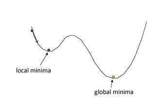

*Gradient Descent*

## Metropolisâ“Hastings algorithm

[Metropolis algorithm](https://en.wikipedia.org/wiki/Metropolis%E2%80%93Hastings_algorithm) (symmetric proposal distribution) Let f(x) be a function that is proportional to the desired probability distribution P(x)

This algorithm proceeds by randomly attempting to move about the sample space, sometimes accepting the moves and sometimes remaining in place.

Perturb (randomly) the current state to a new state. $\Delta E$ is the difference in energy between current and new state.  
If $\Delta E < 0$ (new state is lower), accept new state as current state If $\Delta E > 0$ accept new state with probability inversely proportional to the increase in system energy. Traditionally the change in [Gibbs free energy](https://en.wikipedia.org/wiki/Gibbs_free_energy) is used for thermodynamic free energy systems.

This can be run for a fixed number of iterations or if the overall system energy can measured then it can be run until the overall system energy settles.

## Simulated Annealing Pseudocode

Simulated Annealing uses the Metropolisâ“Hastings algorithm with a temperature parameter $T$ that effects the acceptance probability of an”uphill" transition. At higher“temperatures” accpeting “uphill” transitions is more probable. The algorithm starts initially with $T$ set to a high value , and then it is decreased at each step following some annealing scheduleâwhich is often specified by the user, but must end with $T=0$. At $T=0$ there is no chance of accpeting “uphill” transitions and so it becomes gradient descent.

At a fixed temperature T:  
Perturb (randomly) the current state to a new state. $\Delta E$ is the difference in energy between current and new state.  
If $\Delta E < 0$ (new state is lower), accept new state as current state If $\Delta E > 0$ accept new state with probability inversely proportional to the increase in system energy as a function of T.

Eventually the systems evolves into thermal equilibrium at temperature T ; then the formula mentioned before holds When equilibrium is reached, temperature T can be lowered and the process can be repeated.

# Travelling Salesman Problem

The travelling salesman problem (TSP) asks the following question: Given a list of cities and the distances between each pair of cities, what is the shortest possible route that visits each city exactly once and returns to the origin city? It is an NP-hard problem in combinatorial optimization, important in operations research and theoretical computer science.

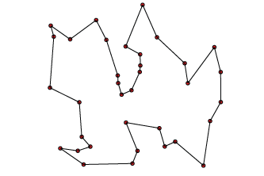

*Travelling Salesman Problem*

# Simulated Annealing to solve the Travelling Salesman Problem in R

Simulated Annealing to solve the Travelling Salesman Problem in R

```r
CityDistMatx <- as.matrix(eurodist)
CityDistMatx
```

```
##                 Athens Barcelona Brussels Calais Cherbourg Cologne
## Athens               0      3313     2963   3175      3339    2762
## Barcelona         3313         0     1318   1326      1294    1498
## Brussels          2963      1318        0    204       583     206
## Calais            3175      1326      204      0       460     409
## Cherbourg         3339      1294      583    460         0     785
## Cologne           2762      1498      206    409       785       0
## Copenhagen        3276      2218      966   1136      1545     760
## Geneva            2610       803      677    747       853    1662
## Gibraltar         4485      1172     2256   2224      2047    2436
## Hamburg           2977      2018      597    714      1115     460
## Hook of Holland   3030      1490      172    330       731     269
## Lisbon            4532      1305     2084   2052      1827    2290
## Lyons             2753       645      690    739       789     714
## Madrid            3949       636     1558   1550      1347    1764
## Marseilles        2865       521     1011   1059      1101    1035
## Milan             2282      1014      925   1077      1209     911
## Munich            2179      1365      747    977      1160     583
## Paris             3000      1033      285    280       340     465
## Rome               817      1460     1511   1662      1794    1497
## Stockholm         3927      2868     1616   1786      2196    1403
## Vienna            1991      1802     1175   1381      1588     937
##                 Copenhagen Geneva Gibraltar Hamburg Hook of Holland Lisbon
## Athens                3276   2610      4485    2977            3030   4532
## Barcelona             2218    803      1172    2018            1490   1305
## Brussels               966    677      2256     597             172   2084
## Calais                1136    747      2224     714             330   2052
## Cherbourg             1545    853      2047    1115             731   1827
## Cologne                760   1662      2436     460             269   2290
## Copenhagen               0   1418      3196     460             269   2971
## Geneva                1418      0      1975    1118             895   1936
## Gibraltar             3196   1975         0    2897            2428    676
## Hamburg                460   1118      2897       0             550   2671
## Hook of Holland        269    895      2428     550               0   2280
## Lisbon                2971   1936       676    2671            2280      0
## Lyons                 1458    158      1817    1159             863   1178
## Madrid                2498   1439       698    2198            1730    668
## Marseilles            1778    425      1693    1479            1183   1762
## Milan                 1537    328      2185    1238            1098   2250
## Munich                1104    591      2565     805             851   2507
```

[output cut: 33 more lines]

```
## Copenhagen        1455
## Geneva            1019
## Gibraltar         2974
## Hamburg           1155
## Hook of Holland   1205
## Lisbon            2937
## Lyons             1157
## Madrid            2409
## Marseilles        1363
## Milan              898
## Munich             428
## Paris             1249
## Rome              1209
## Stockholm         2105
## Vienna               0
```

```r
# Distance function
distance <- function(sq)
  {  # Target function
  sq2 <- embed(sq, 2)
  return(as.numeric(sum(CityDistMatx[cbind(sq2[,2],sq2[,1])])))
}

# Generate new candidates
GenSeq <- function(sq) {  # Generate new candidate sequence
  idx <- seq(2, NROW(CityDistMatx)-1, by=1)
  ChangePoints <- sample(idx, size=2, replace=FALSE)
  tmp <- sq[ChangePoints[1]]
  sq[ChangePoints[1]] <- sq[ChangePoints[2]]
  sq[ChangePoints[2]] <- tmp
  return(as.numeric(sq))
}

cities<-labels(eurodist)
cities
```

```
##  [1] "Athens"          "Barcelona"       "Brussels"
##  [4] "Calais"          "Cherbourg"       "Cologne"
##  [7] "Copenhagen"      "Geneva"          "Gibraltar"
## [10] "Hamburg"         "Hook of Holland" "Lisbon"
## [13] "Lyons"           "Madrid"          "Marseilles"
## [16] "Milan"           "Munich"          "Paris"
## [19] "Rome"            "Stockholm"       "Vienna"
```

```r
initial.tour <- c(1,2:NROW(CityDistMatx),1)
# Initial sequence
initial.tour
```

```
##  [1]  1  2  3  4  5  6  7  8  9 10 11 12 13 14 15 16 17 18 19 20 21  1
```

```r
initial.d<-distance(initial.tour)
initial.d
```

```
## [1] 29625
```

```r
for(i in 1:length(initial.tour))
{
  print(cities[initial.tour[i]])
}
```

```
## [1] "Athens"
## [1] "Barcelona"
## [1] "Brussels"
## [1] "Calais"
## [1] "Cherbourg"
## [1] "Cologne"
## [1] "Copenhagen"
## [1] "Geneva"
## [1] "Gibraltar"
## [1] "Hamburg"
## [1] "Hook of Holland"
## [1] "Lisbon"
## [1] "Lyons"
## [1] "Madrid"
## [1] "Marseilles"
## [1] "Milan"
## [1] "Munich"
## [1] "Paris"
## [1] "Rome"
## [1] "Stockholm"
## [1] "Vienna"
## [1] "Athens"
```

```r
set.seed(333) # chosen to get a good soln relatively quickly

#  box-constrained optimization and simulated annealing
# method = "SANN" performs simulated annealing
# Method "SANN" is by default a variant of simulated annealing given in Belisle (1992)
res <- optim(initial.tour, distance, GenSeq, method = "SANN",
             control = list(maxit = 30000, temp = 2000, trace = TRUE,
                            REPORT = 500))
```

```
## sann objective function values
## sann stopped after 29999 iterations
```

```r
res  # Near optimum distance around 12842
```

```
## $par
##  [1]  1 19 16 15  2 14  9 12 13  8 18  5  4  3 11  7 20 10  6 17 21  1
##
## $value
## [1] 12907
##
## $counts
## function gradient
##    30000       NA
##
## $convergence
## [1] 0
##
## $message
## NULL
```

```r
final.tour<-res$par
final.tour
```

```
##  [1]  1 19 16 15  2 14  9 12 13  8 18  5  4  3 11  7 20 10  6 17 21  1
```

```r
final.d<-distance(final.tour)
final.d
```

```
## [1] 12907
```

```r
initial.d
```

```
## [1] 29625
```

```r
final.d/initial.d
```

```
## [1] 0.4356793
```

```r
cities.xy <- cmdscale(eurodist)
cities.xy
```

```
##                         [,1]        [,2]
## Athens           2290.274680  1798.80293
## Barcelona        -825.382790   546.81148
## Brussels           59.183341  -367.08135
## Calais            -82.845973  -429.91466
## Cherbourg        -352.499435  -290.90843
## Cologne           293.689633  -405.31194
## Copenhagen        681.931545 -1108.64478
## Geneva             -9.423364   240.40600
## Gibraltar       -2048.449113   642.45854
## Hamburg           561.108970  -773.36929
## Hook of Holland   164.921799  -549.36704
## Lisbon          -1935.040811    49.12514
## Lyons            -226.423236   187.08779
## Madrid          -1423.353697   305.87513
## Marseilles       -299.498710   388.80726
## Milan             260.878046   416.67381
## Munich            587.675679    81.18224
## Paris            -156.836257  -211.13911
## Rome              709.413282  1109.36665
## Stockholm         839.445911 -1836.79055
## Vienna            911.230500   205.93020
```

```r
for(i in 1:length(final.tour))
{
  print(cities[final.tour[i]])
}
```

```
## [1] "Athens"
## [1] "Rome"
## [1] "Milan"
## [1] "Marseilles"
## [1] "Barcelona"
## [1] "Madrid"
## [1] "Gibraltar"
## [1] "Lisbon"
## [1] "Lyons"
## [1] "Geneva"
## [1] "Paris"
## [1] "Cherbourg"
## [1] "Calais"
## [1] "Brussels"
## [1] "Hook of Holland"
## [1] "Copenhagen"
## [1] "Stockholm"
## [1] "Hamburg"
## [1] "Cologne"
## [1] "Munich"
## [1] "Vienna"
## [1] "Athens"
```

```r
rx <- range(x <- cities.xy[,1])
ry <- range(y <- -cities.xy[,2])
rx
```

```
## [1] -2048.449  2290.275
```

```r
ry
```

```
## [1] -1798.803  1836.791
```

```r
x
```

```
##          Athens       Barcelona        Brussels          Calais
##     2290.274680     -825.382790       59.183341      -82.845973
##       Cherbourg         Cologne      Copenhagen          Geneva
##     -352.499435      293.689633      681.931545       -9.423364
##       Gibraltar         Hamburg Hook of Holland          Lisbon
##    -2048.449113      561.108970      164.921799    -1935.040811
##           Lyons          Madrid      Marseilles           Milan
##     -226.423236    -1423.353697     -299.498710      260.878046
##          Munich           Paris            Rome       Stockholm
##      587.675679     -156.836257      709.413282      839.445911
##          Vienna
##      911.230500
```

```r
y
```

```
##          Athens       Barcelona        Brussels          Calais
##     -1798.80293      -546.81148       367.08135       429.91466
##       Cherbourg         Cologne      Copenhagen          Geneva
##       290.90843       405.31194      1108.64478      -240.40600
##       Gibraltar         Hamburg Hook of Holland          Lisbon
##      -642.45854       773.36929       549.36704       -49.12514
##           Lyons          Madrid      Marseilles           Milan
##      -187.08779      -305.87513      -388.80726      -416.67381
##          Munich           Paris            Rome       Stockholm
##       -81.18224       211.13911     -1109.36665      1836.79055
##          Vienna
##      -205.93020
```

```r
initial.tour
```

```
##  [1]  1  2  3  4  5  6  7  8  9 10 11 12 13 14 15 16 17 18 19 20 21  1
```

```r
## remove last element to draw arrows from point to point
s <-head(initial.tour, -1)
s
```

```
##  [1]  1  2  3  4  5  6  7  8  9 10 11 12 13 14 15 16 17 18 19 20 21
```

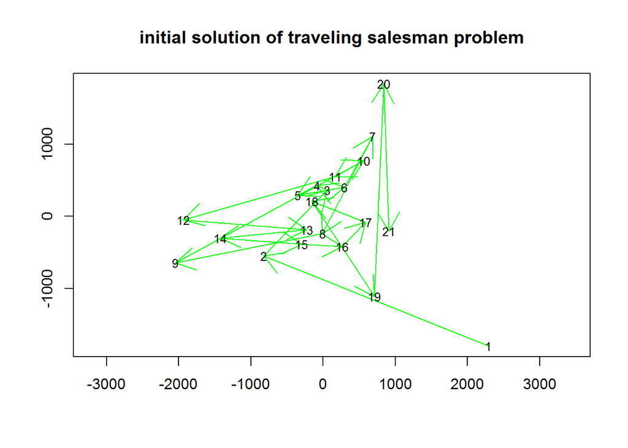

```r
plot(x, y, type="n", asp=1, xlab="", ylab="", main="initial solution of traveling salesman problem")
arrows(x[s], y[s], x[s+1], y[s+1], col="green")
text(x, y, labels(cities), cex=0.8)
```

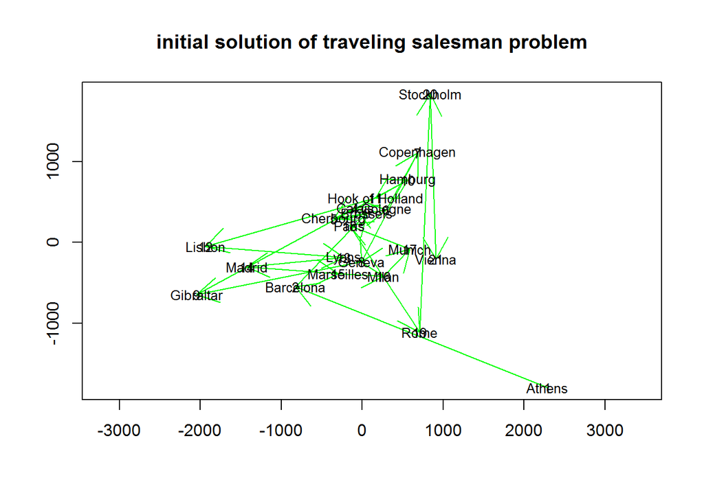

```r
plot(x, y, type="n", asp=1, xlab="", ylab="", main="initial solution of traveling salesman problem")
arrows(x[s], y[s], x[s+1], y[s+1], col="green")
text(x, y, labels(cities), cex=0.8)
text(x, y, labels(eurodist), cex=0.8)
```

```r
final.tour
```

```
##  [1]  1 19 16 15  2 14  9 12 13  8 18  5  4  3 11  7 20 10  6 17 21  1
```

```r
## draw lines from point to point
s <-head(final.tour, -1)
s
```

```
##  [1]  1 19 16 15  2 14  9 12 13  8 18  5  4  3 11  7 20 10  6 17 21
```

```r
df = data.frame(x[s],y[s])
df
```

```
##                         x.s.        y.s.
## Athens           2290.274680 -1798.80293
## Rome              709.413282 -1109.36665
## Milan             260.878046  -416.67381
## Marseilles       -299.498710  -388.80726
## Barcelona        -825.382790  -546.81148
## Madrid          -1423.353697  -305.87513
## Gibraltar       -2048.449113  -642.45854
## Lisbon          -1935.040811   -49.12514
## Lyons            -226.423236  -187.08779
## Geneva             -9.423364  -240.40600
## Paris            -156.836257   211.13911
## Cherbourg        -352.499435   290.90843
## Calais            -82.845973   429.91466
## Brussels           59.183341   367.08135
## Hook of Holland   164.921799   549.36704
## Copenhagen        681.931545  1108.64478
## Stockholm         839.445911  1836.79055
## Hamburg           561.108970   773.36929
## Cologne           293.689633   405.31194
## Munich            587.675679   -81.18224
## Vienna            911.230500  -205.93020
```

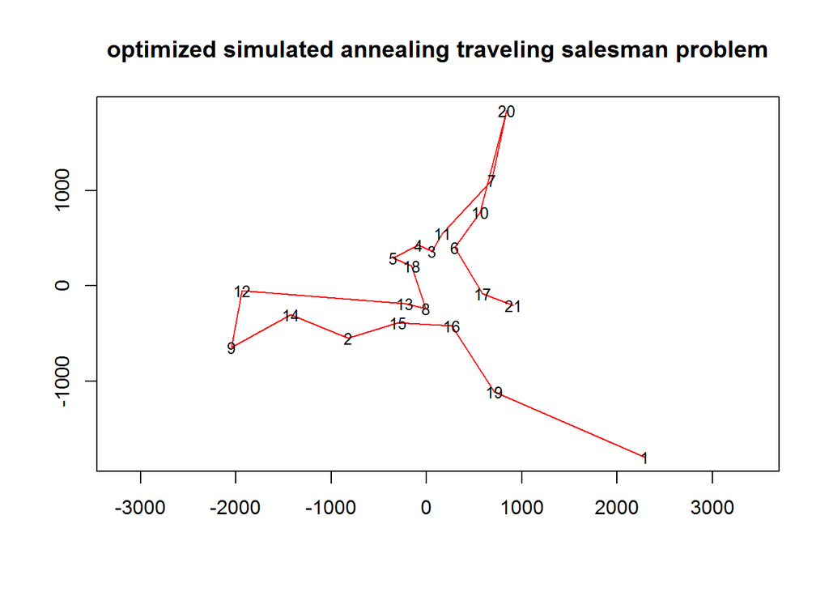

```r
plot(x, y, type="n", asp=1, xlab="", ylab="", main="optimized simulated annealing traveling salesman problem")
lines(df$x, df$y, col="red")
text(x, y, labels(cities), cex=0.8)
```

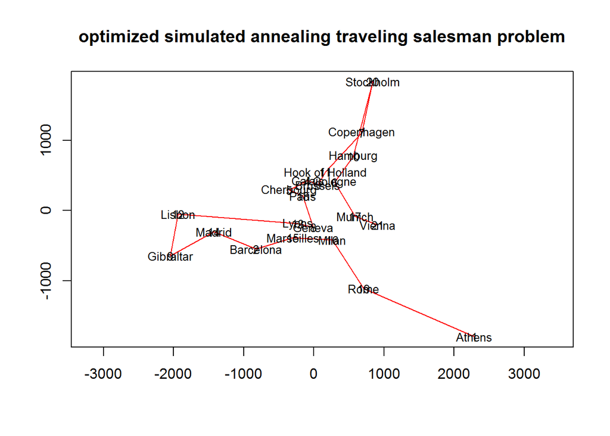

```r
plot(x, y, type="n", asp=1, xlab="", ylab="", main="optimized simulated annealing traveling salesman problem")
lines(df$x, df$y, col="red")
text(x, y, labels(cities), cex=0.8)
text(x, y, labels(eurodist), cex=0.8)
```

# Assingment

Use simulated annealing to search for a solution to the famous Travelling Salesman Problem in R.  
* . Answer the following questions:  
* Write a different distance function. How does the effect the final solution?  
* Does scaling, normalization or leaving the data unscaled make a difference for simulated annealing?  
* Try a few differnt initial tours. How does the effect the final solution?

# Resources

- [The Traveling Salesman with Simulated Annealing, R, and Shiny](http://toddwschneider.com/posts/traveling-salesman-with-simulated-annealing-r-and-shiny/)
- [Simulated Annealing Feature Selection](http://www.r-bloggers.com/simulated-annealing-feature-selection/)

```